# Lab 3

Author

Trenton Tadaki

# Data Set

The data set `hiphop` contains results from a study conducted by a linguist at the University of Minnesota. The researcher was interested in predicting musical taste based on familiarity with African American English (AAE). 168 subjects participated in the study, and each was asked to define 64 different AAE terms. The definitions given were used to create a `familiarity` score for each subject for each term. This score quantifies how well the subject knew the term on a scale of 1-5 (1 = not at all, 5 = very well). Before tackling the problems, study the description of each variable [here](http://conservancy.umn.edu/bitstream/handle/11299/116327/5/explanationAAEHiphopChesley.txt).

**1. Load the appropriate R packages and import the data set, `hiphop`.**

```r
# code chunk for loading packages and importing the data
library(tidyverse)
hiphop <- read_csv(here::here("Week 3", "Lab 3", "hiphop.csv"))
```

## Summary

**2. Provide a brief overview (2-4 sentences) of the data set.**

This data set includes 168 responses from undergraduate University of Minnesota students enrolled in linguistics, sociology, and music. The data includes demographic variables, a 1-5 ranking system on the familiarity of a number of African-American English vocabulary, and questions regarding close relationships with specific ethnicities and familiarity with variations of pop-culture and music. The data was collected for the purpose of identifying a correlation between recognition of AAE language and music taste.

**3. What are the rows of this data set?**

**Warning**

It is not one person per row!

```r
str(hiphop)
```

```
spc_tbl_ [10,752 × 38] (S3: spec_tbl_df/tbl_df/tbl/data.frame)
 $ word               : chr [1:10752] "[to be] ghost" "[to be] ghost" "[to be] ghost" "[to be] ghost" ...
 $ subj               : chr [1:10752] "p15" "p53" "p136" "p36" ...
 $ sex                : chr [1:10752] "Female" "Female" "Male" "Female" ...
 $ age                : num [1:10752] 20 17 41 18 18 19 18 18 19 19 ...
 $ ethnic             : chr [1:10752] "white" "white" "white" "white" ...
 $ city               : num [1:10752] 33283 34033 8789 712 24280 ...
 $ county             : num [1:10752] 1156212 396500 58696 148955 153504 ...
 $ intl               : num [1:10752] 0 0 0 0 0 0 0 0 0 0 ...
 $ vocal              : num [1:10752] 0 0 2 0 3 0 0 0 0 1 ...
 $ classical          : num [1:10752] 0 0 0 0 3 0 0 0 0 0 ...
 $ folk               : num [1:10752] 0 0 0 1 0 0 2 0 0 0 ...
 $ rock               : num [1:10752] 1 0 0 1 1 0 0 1 0 4 ...
 $ country            : num [1:10752] 3 1 0 2 0 1 0 3 0 4 ...
 $ pop                : num [1:10752] 4 3 0 2 3 1 0 1 0 4 ...
 $ alternative        : num [1:10752] 1 0 0 3 1 0 3 1 0 4 ...
 $ hiphop             : num [1:10752] 7 3 0 3 0 3 0 4 5 0 ...
 $ unclassifiable     : num [1:10752] 0 0 0 0 0 0 0 0 0 0 ...
 $ countyBlack        : num [1:10752] 126221 18064 413 24 6115 ...
 $ jayz               : num [1:10752] 5 5 1 5 1 5 5 5 5 1 ...
 $ barkley            : num [1:10752] 5 1 1 3 1 5 1 2 5 1 ...
 $ boondocks          : num [1:10752] 1 1 1 1 1 1 1 5 5 1 ...
 $ monique            : num [1:10752] 4 3 1 1 1 1 3 1 3 1 ...
 $ bieber             : num [1:10752] 6 6 1 4 2 3 2.5 1 2 2 ...
 $ asianMove          : num [1:10752] 3 0 0 1 0.75 0 0 0 5 1 ...
 $ blackMove          : num [1:10752] 3 0 0 0 0.592 ...
 $ hispanicMove       : num [1:10752] 2 1 0 0 0.353 ...
 $ nativeMove         : num [1:10752] 0 0 0 0 0.0318 ...
 $ SAAMEMove          : num [1:10752] 0 0 0 0 0.295 ...
 $ whiteMove          : num [1:10752] 9 1 2 9 6.29 ...
 $ blackWeekly        : num [1:10752] 3 0 0 1 5 3 2 7 6 1 ...
 $ jayz1              : num [1:10752] 1 1 0 1 0 1 1 1 1 0 ...
 $ boondocks1         : num [1:10752] 0 0 0 0 0 0 0 1 1 0 ...
 $ familiarity        : num [1:10752] 1 1 1 1 1 1 1 1 5 1 ...
 $ trial              : num [1:10752] 26 14 3 12 53 23 25 16 2 29 ...
 $ fam1               : num [1:10752] 0 0 0 0 0 0 0 0 1 0 ...
 $ popularityScore    : num [1:10752] 33 33 33 33 33 33 33 33 33 33 ...
 $ numPreferredArtists: num [1:10752] 1 1 NA 0 NA 0 NA 1 0 NA ...
 $ numOverallArtists  : num [1:10752] 7 7 NA 7 NA 7 NA 7 7 NA ...
 - attr(*, "spec")=
```

[output cut: 26 more lines]

[output not shown]

**4. Missing values for some of the variables were replaced with other values. How were missing values replaced? What do you believe are some benefits and drawbacks of doing this?**

For the variables asking for the number of strong ties participants had with a given ethnicity, the missing values were replaced with mean values for the variable. A benefit of this method is that it does not affect the summarized mean of the variable, but a downside is that it may cause confusion when identifying individual observations. Additionally, for the number of overall/preferred artists who who used the word in their songs, the missing values were replaced by NA. This is beneficial in that it can be easily removed when finding summary statistics of the data, but it makes it difficult when making analyses to use observations that are missing values. Lastly, for the demographic questions, city and county, values of 0 were used for the missing values, which is a poor choice since it can skew the data.

**5. Clean the data set in whichever ways you see fit. This might mean adjusting *variable type*, for example from `character` to `factor`, or dealing with missing data. Assign your cleaned data set to a new data set named `hiphop_clean` – use this data set going forward.**

**Tip**

Helpful functions: `mutate()`, `as.factor()`

Likert scales (1-5) will be read by R as numeric values and MUST be converted to factors.

It would be most efficient to use `across()` in combination with `mutate()` to complete this task.

```r
# code chunk for Q5
hiphop_clean <- hiphop |>
  drop_na(numPreferredArtists,
          numOverallArtists) |>
  mutate(
    across(
      c(jayz, barkley, boondocks, monique, bieber, familiarity, fam1),
      as.factor))
```

# Data Summaries

**6. How many unique AAE words were studied in this data set?**

**Tip**

Helpful functions: `distinct()`, `count()`

```r
# code chunk for Q6
unique_words <- hiphop_clean |>
  distinct(word)
nrow(unique_words)
```

```
[1] 64
```

64 Unique AAE words were studied in this data set

**7. Make a new variable that re-categorizes `ethnic` into only two groups, “white” and “non-white”, to simplify your data.**

```r
# code chunk for Q7
hiphop_clean <- hiphop_clean |>
  mutate(
    ethnic = if_else(ethnic == 'white',
                     'white',
                     'non-white'))
```

**8. It is fairly common for researchers to collapse ethnic or racial categories similar to what you just did. What are some issues with representing the data in this way?**

Generalizing racial or ethnic categories often leads to controversial findings because it discredits the individual experiences and cultures that define groups of people and can also lead to false notions.

**9. What are the demographics of the people in this study? Investigate the variables `sex`, `age`, and `ethnic` and summarize your findings in 1-3 complete sentences.**

**Tip**

You’ll need to first manipulate your data to have each person represented only once.

Helpful functions: `select()`, `distinct(___, .keep_all = TRUE)`, `count()`, `summary()`

```r
# code chunk for Q9
hiphop_individs <- hiphop_clean |>
  select(subj, sex, age, ethnic) |>
  distinct(subj, .keep_all = TRUE)

hiphop_individs |>
  count(sex)
```

```
# A tibble: 2 × 2
  sex        n
  <chr>  <int>
1 Female    56
2 Male      24
```

```r
hiphop_individs |>
  count(ethnic)
```

```
# A tibble: 2 × 2
  ethnic        n
  <chr>     <int>
1 non-white    18
2 white        62
```

```r
hiphop_individs |>
  summary(age)
```

```
     subj               sex                 age           ethnic
 Length:80          Length:80          Min.   :16.00   Length:80
 Class :character   Class :character   1st Qu.:18.00   Class :character
 Mode  :character   Mode  :character   Median :18.00   Mode  :character
                                       Mean   :19.55
                                       3rd Qu.:20.00
                                       Max.   :42.00
```

There are 56 females (70% of the data set) and 24 males (30% of the data set). There are 18 non-white individuals (22.5% of the data set) and 62 white individuals (77.5% of the data set). The mean age of the data set is 19.55 years old, the minimum age is 16 y/o, and the maximum age is 42 y/o.

**10. Make at least two plots to display the demographic information of the subjects in this study.**

**Note**

You do not need to discuss these plots, but make sure they are appropriate to the data types and have informative titles and axis labels. Feel free to use the skills you learned in Challenge 2 to enhance your plots!

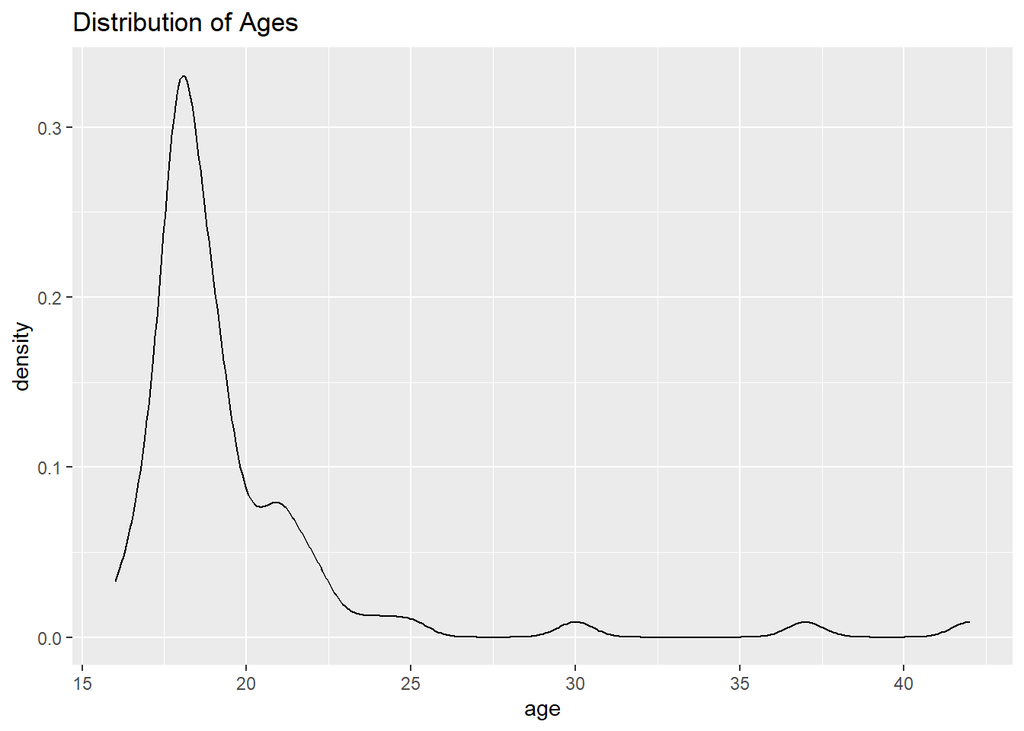

```r
# code chunk for Q10
ggplot(data = hiphop_individs) +
  geom_density(mapping = aes(x = age)) +
  labs(title = 'Distribution of Ages')
```

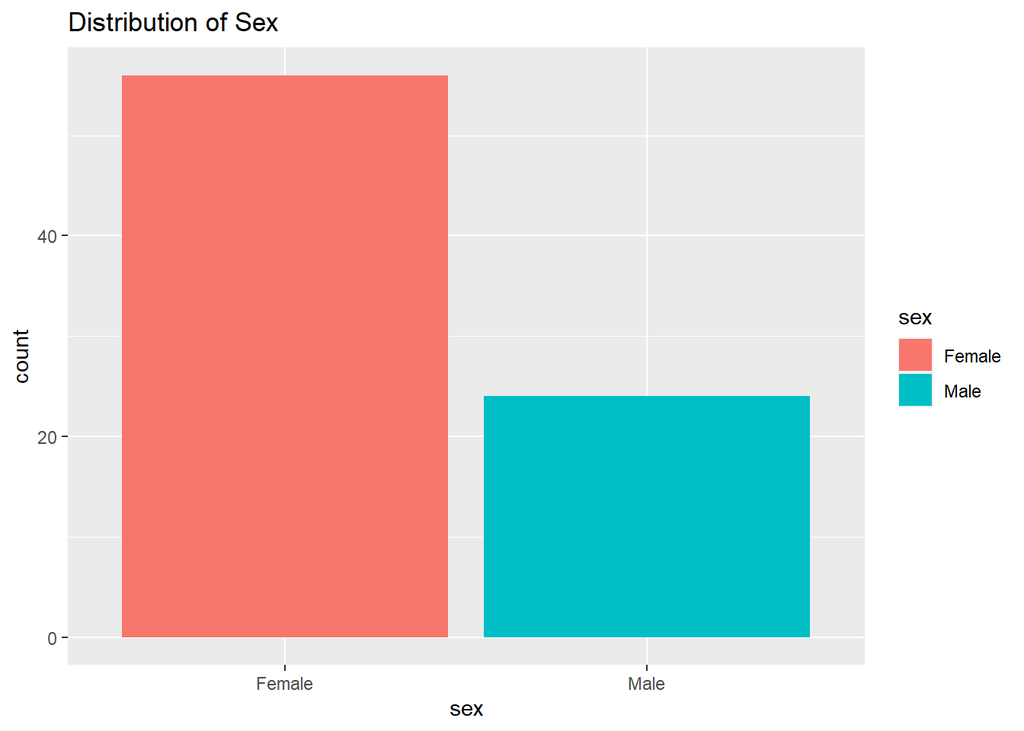

```r
ggplot(data = hiphop_individs,
       mapping = aes(x = sex)) +
  geom_bar(mapping = aes(fill = sex)) +
  labs(title = 'Distribution of Sex')
```

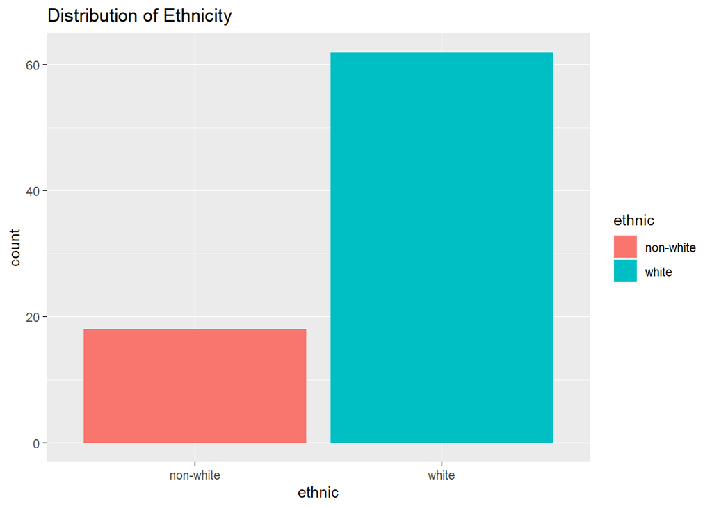

```r
ggplot(data = hiphop_individs,
       mapping = aes(x = ethnic)) +
  geom_bar(mapping = aes(fill = ethnic)) +
  labs(title = 'Distribution of Ethnicity')
```

## Familiar words

For each demographic group listed below, determine which word(s) in this study was(were) the most **and** least familiar on average.

**Tip**

Helpful functions: `filter()`, `group_by()`, `summarize()`, `slice_max()`, `slice_min()`

Useful variables: `word`, `familiarity`, `sex`, `age`, `ethnic`

**11. People below the age of 20.**

```r
# code chunk for Q11
hiphop_clean |>
  filter(age < 20) |>
  group_by(word) |>
  summarize(mean_fam = mean(as.numeric(familiarity))) |>
  slice_min(mean_fam)
```

```
# A tibble: 1 × 2
  word       mean_fam
  <chr>         <dbl>
1 The Nation        1
```

```r
#The least familiar word among people below the age of 20 is 'The Nation'

hiphop_clean |>
  filter(age < 20) |>
  group_by(word) |>
  summarize(mean_fam = mean(as.numeric(familiarity))) |>
  slice_max(mean_fam)
```

```
# A tibble: 1 × 2
  word    mean_fam
  <chr>      <dbl>
1 feel me     4.52
```

```r
#The most familiar word among people below the age of 20 is 'feel me'
```

**12. Non-white women.**

```r
# code chunk for Q12

hiphop_clean |>
  filter(ethnic == 'non-white',
         sex == 'Female') |>
  group_by(word) |>
  summarize(mean_fam = mean(as.numeric(familiarity))) |>
  slice_min(mean_fam)
```

```
# A tibble: 8 × 2
  word              mean_fam
  <chr>                <dbl>
1 break someone out        1
2 dollar cab               1
3 domino                   1
4 dukey rope               1
5 humming                  1
6 plex                     1
7 rollie                   1
8 The Nation               1
```

```r
#The least familiar words among non-white women are 'break someone out', 'dollar cab', 'domino', 'dukey rope', 'humming', 'plex', 'rollie', and 'The Nation'.

hiphop_clean |>
  filter(ethnic == 'non-white',
         sex == 'Female') |>
  group_by(word) |>
  summarize(mean_fam = mean(as.numeric(familiarity))) |>
  slice_max(mean_fam)
```

```
# A tibble: 1 × 2
  word       mean_fam
  <chr>         <dbl>
1 what it do     4.57
```

```r
#The most familiar word among among non-white women is 'what it do'.
```

**13. White men above the age of 30.**

```r
# code chunk for Q13
hiphop_clean |>
  filter(ethnic == 'white',
         sex == 'Male',
         age > 30) |>
  group_by(word) |>
  summarize(mean_fam = mean(as.numeric(familiarity))) |>
  slice_min(mean_fam)
```

```
# A tibble: 59 × 2
   word              mean_fam
   <chr>                <dbl>
 1 [to be] ghost            1
 2 A-town                   1
 3 ashy                     1
 4 ay yo trip               1
 5 ballin'                  1
 6 beezy                    1
 7 bones                    1
 8 boo                      1
 9 boughie                  1
10 break someone out        1
# … with 49 more rows
```

```r
#Since there was only one particpant who fell under these demographics, all of his responses for words that were rated 1 count as the minimum average rating.

hiphop_clean |>
  filter(ethnic == 'white',
         sex == 'Male',
         age > 30) |>
  group_by(word) |>
  summarize(mean_fam = mean(as.numeric(familiarity))) |>
  slice_max(mean_fam)
```

```
# A tibble: 3 × 2
  word         mean_fam
  <chr>           <dbl>
1 5-0                 5
2 hard                5
3 make it rain        5
```

```r
#The most familiar word among among white men above 30 is '5-0', 'hard', and 'make it rain'.
```

## Study Subjects

A joke among the [Tidy Tuesday](https://www.tidytuesday.com/) community is that Justin Bieber was one of the subjects in this study. Bieber, a white male, from a relatively small town (10,000-60,000 people) in Ontario would have been 17-23 at the time of the study.

**14. Determine which subject you believe is secretly Bieber, justify your answer.**

**Tip**

Refer again to the data set description. There is another clue about Bieber’s identity.

```r
# code chunk for Q14
hiphop_clean |>
  distinct(subj, .keep_all = TRUE) |>
  filter(ethnic == 'white',
         sex == 'Male',
         age >= 17 & age <= 23) |>
  slice_max(bieber)
```

```
# A tibble: 1 × 38
  word     subj  sex     age ethnic  city county  intl vocal class…¹  folk  rock
  <chr>    <chr> <chr> <dbl> <chr>  <dbl>  <dbl> <dbl> <dbl>   <dbl> <dbl> <dbl>
1 [to be]… p17   Male     18 white  56377 331582     0     1       0     0     1
# … with 26 more variables: country <dbl>, pop <dbl>, alternative <dbl>,
#   hiphop <dbl>, unclassifiable <dbl>, countyBlack <dbl>, jayz <fct>,
#   barkley <fct>, boondocks <fct>, monique <fct>, bieber <fct>,
#   asianMove <dbl>, blackMove <dbl>, hispanicMove <dbl>, nativeMove <dbl>,
#   SAAMEMove <dbl>, whiteMove <dbl>, blackWeekly <dbl>, jayz1 <dbl>,
#   boondocks1 <dbl>, familiarity <fct>, trial <dbl>, fam1 <fct>,
#   popularityScore <dbl>, numPreferredArtists <dbl>, …
```

I believe Justin Bieber is particpant 17. He is the only participant to be able to name 5 Justin Bieber songs, and his demographics/hometown match that of Justin Bieber’s.

# Lab 3 Submission

You will submit **only** your rendered HTML file. Your HTML file is required to have the following specifications in the YAML options (at the top of your document):

- be self-contained (`self-contained: true`)
- include your source code (`code-tools: true`)
- include all your code and output (`echo: true`)
- include **no** messages from loading in packages or the data (`messages: false`)

**If any of the options are not included, your Lab 3 or Challenge 3 assignment will receive an “Incomplete” and you will be required to submit a revision.**